# R Notebook

```r
library(tidyverse)
library(GGally)
library(ggfortify)
red <- read_csv("data/wine_quality_red.csv")
white <- read_csv("data/wine_quality_white.csv")
```

# Intend on doing test/train splitting so starting by splitting data

```r
n_data <- nrow(red)

# assigning 20% of data to test
red_test_index <- sample(1: n_data, size = n_data * 0.2)

red_test <- slice(red, red_test_index)
red_train <- slice(red, -red_test_index)


#model will be built using red_train data
```

# Explore data

```r
head(red_train)
```

| wine_id | fixed_acidity | volatile_acidity | citric_acid | residual_sugar | chlorides | free_sulfur_dioxide | total_sulfur_dioxide | density | p_h | sulphates | alcohol | quality | region |
| --- | --- | --- | --- | --- | --- | --- | --- | --- | --- | --- | --- | --- | --- |
| 1 | 7.4 | 0.70 | 0.00 | 1.9 | 0.076 | 11 | 34 | 0.9978 | 3.51 | 0.56 | 9.4 | 4.66 | Australia |
| 2 | 7.8 | 0.88 | 0.00 | 2.6 | 0.098 | 25 | 67 | 0.9968 | 3.20 | 0.68 | 9.8 | 4.82 | Spain |
| 3 | 7.8 | 0.76 | 0.04 | 2.3 | 0.092 | 15 | 54 | 0.9970 | 3.26 | 0.65 | 9.8 | 4.91 | Spain |
| 4 | 11.2 | 0.28 | 0.56 | 1.9 | 0.075 | 17 | 60 | 0.9980 | 3.16 | 0.58 | 9.8 | 5.96 | Australia |
| 5 | 7.4 | 0.70 | 0.00 | 1.9 | 0.076 | 11 | 34 | 0.9978 | 3.51 | 0.56 | 9.4 | 5.42 | Italy |
| 6 | 7.4 | 0.66 | 0.00 | 1.8 | 0.075 | 13 | 40 | 0.9978 | 3.51 | 0.56 | 9.4 | 4.78 | Italy |

# Wine ID seems unnecessary, region could be iffy but migh tbe interesting

# to see what region the model thinks is good wine, leaving in for now, making a factor

```r
red_train <- red_train %>%
  select(-wine_id) %>%
  mutate(region = as.factor(region))
```

# Look at correlations coefficients

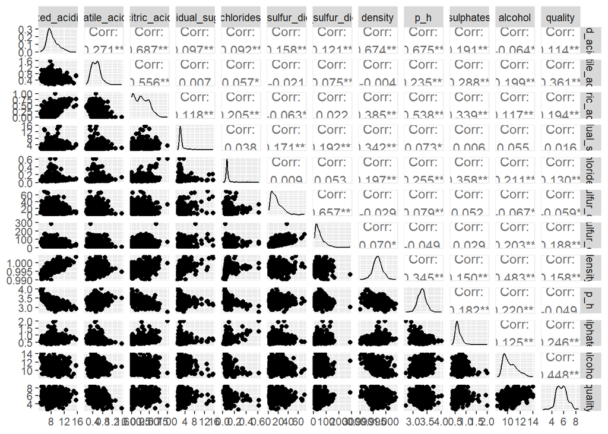

```r
red_train %>%
  select(-region) %>%
  ggpairs()
```

# Cant really read as all squashed so doing ggcorr, so get intial coeff

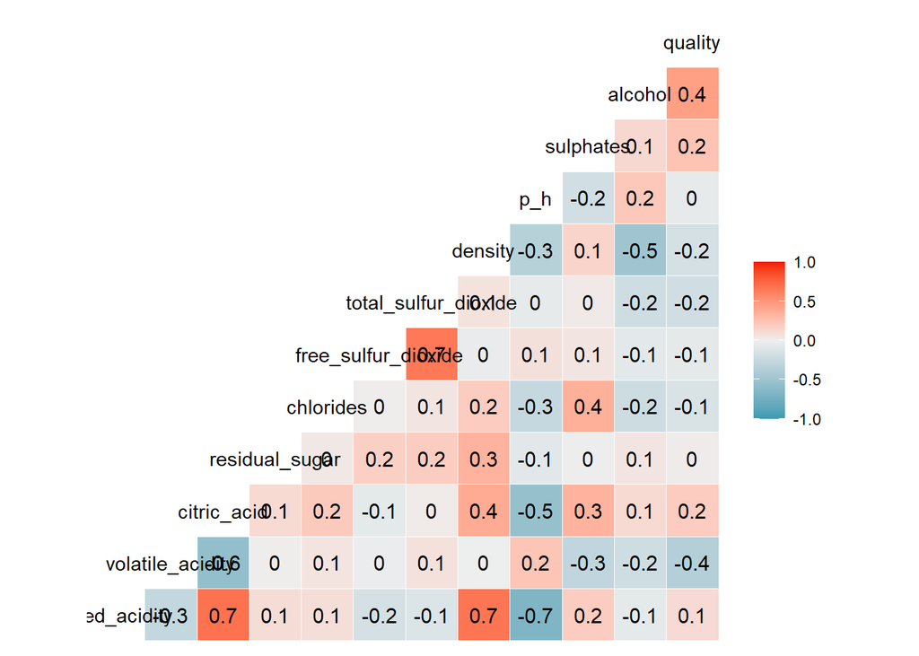

```r
red_train %>%
  ggcorr(label = T)
```

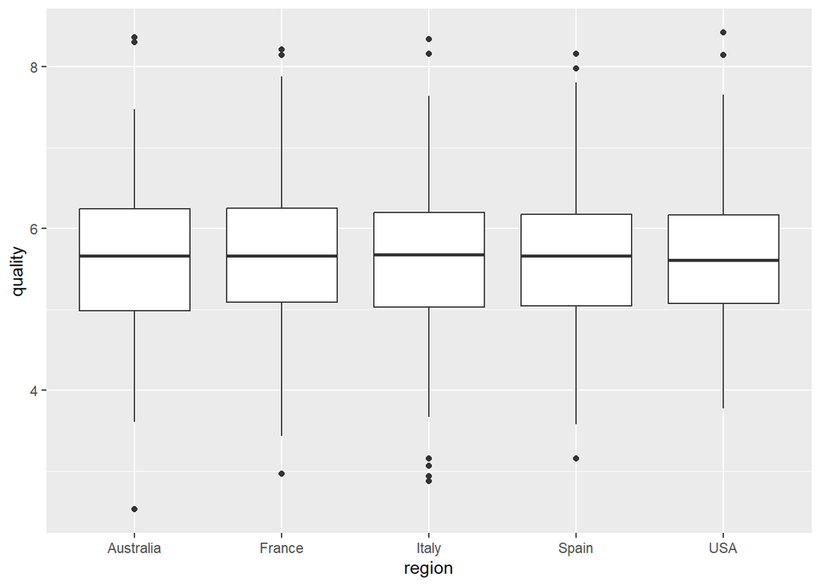

```r
red_train %>%
  ggplot(aes( x = region, y = quality)) +
  geom_boxplot()
```

Seems region has little effect on perceived quality

# Checking for alias variables

```r
alias(quality ~ ., data = red_train)
```

```
## Model :
## quality ~ fixed_acidity + volatile_acidity + citric_acid + residual_sugar +
##     chlorides + free_sulfur_dioxide + total_sulfur_dioxide +
##     density + p_h + sulphates + alcohol + region
```

No aliases, ideal.

# From domain knowledge and above coefficients; starting with sulphates,

# alcohol, total sulfur dioxides, chlorides

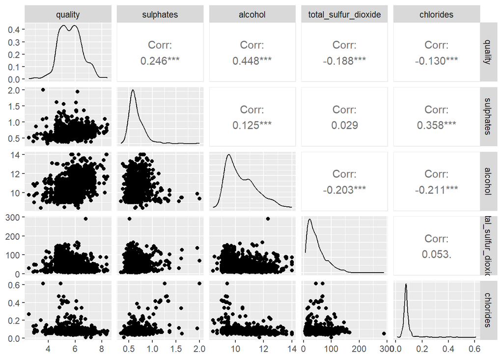

```r
red_train %>%
  select(quality, sulphates, alcohol, total_sulfur_dioxide, chlorides) %>%
  ggpairs()
```

```r
model1 <- lm(quality ~ alcohol, data = red_train)
summary(model1)
```

```
##
## Call:
## lm(formula = quality ~ alcohol, data = red_train)
##
## Residuals:
##      Min       1Q   Median       3Q      Max
## -2.95694 -0.49972 -0.05552  0.51848  2.69751
##
## Coefficients:
##             Estimate Std. Error t value Pr(>|t|)
## (Intercept)  1.90750    0.21108   9.037   <2e-16 ***
## alcohol      0.36050    0.02014  17.899   <2e-16 ***
## ---
## Signif. codes:  0 '***' 0.001 '**' 0.01 '*' 0.05 '.' 0.1 ' ' 1
##
## Residual standard error: 0.7667 on 1278 degrees of freedom
## Multiple R-squared:  0.2004, Adjusted R-squared:  0.1998
## F-statistic: 320.4 on 1 and 1278 DF,  p-value: < 2.2e-16
```

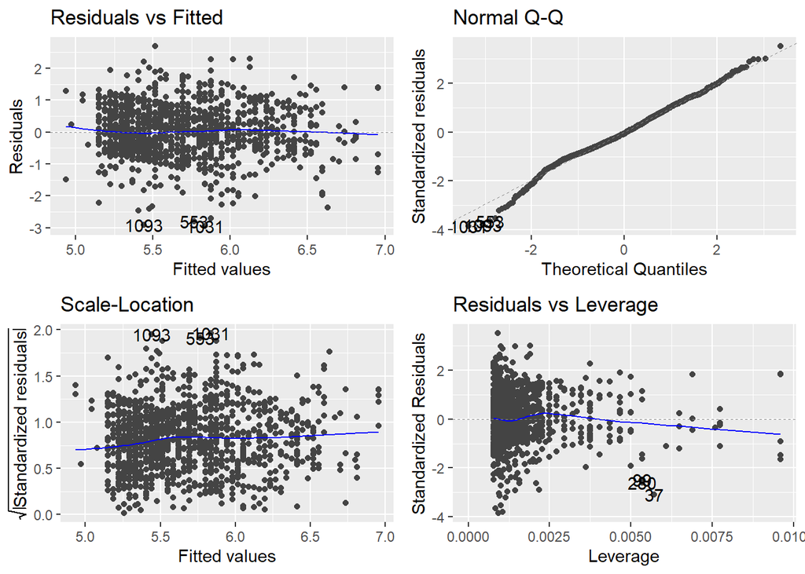

```r
autoplot(model1)
```

Some draw from outliers but minor. Overall solid start. QQ good, and residual placement well scattered.

# Adding sulphates

```r
model2 <- lm(quality ~ alcohol + sulphates, data = red_train)
summary(model2)
```

```
##
## Call:
## lm(formula = quality ~ alcohol + sulphates, data = red_train)
##
## Residuals:
##      Min       1Q   Median       3Q      Max
## -3.06877 -0.46330 -0.01707  0.50283  2.30366
##
## Coefficients:
##             Estimate Std. Error t value Pr(>|t|)
## (Intercept)  1.44546    0.21460   6.736 2.46e-11 ***
## alcohol      0.34110    0.01984  17.194  < 2e-16 ***
## sulphates    1.01347    0.12969   7.815 1.14e-14 ***
## ---
## Signif. codes:  0 '***' 0.001 '**' 0.01 '*' 0.05 '.' 0.1 ' ' 1
##
## Residual standard error: 0.7493 on 1277 degrees of freedom
## Multiple R-squared:  0.2369, Adjusted R-squared:  0.2357
## F-statistic: 198.3 on 2 and 1277 DF,  p-value: < 2.2e-16
```

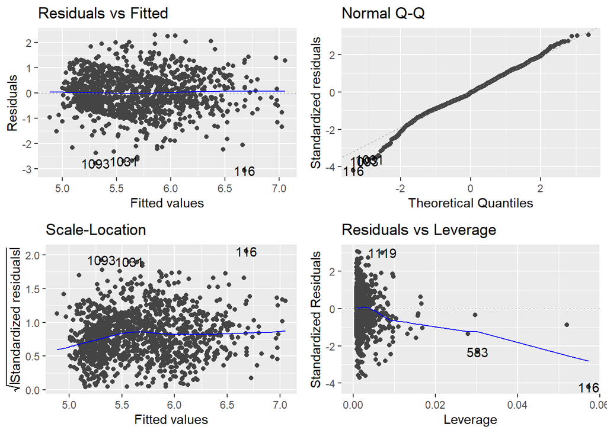

```r
autoplot(model2)
```

Residuals remain acceptable

# Adding Chlorides

```r
model3 <- lm(quality ~ alcohol + sulphates + chlorides, data = red_train)
summary(model3)
```

```
##
## Call:
## lm(formula = quality ~ alcohol + sulphates + chlorides, data = red_train)
##
## Residuals:
##      Min       1Q   Median       3Q      Max
## -2.60672 -0.47152 -0.01289  0.49736  2.27994
##
## Coefficients:
##             Estimate Std. Error t value Pr(>|t|)
## (Intercept)  1.77487    0.22240   7.980 3.22e-15 ***
## alcohol      0.31270    0.02044  15.295  < 2e-16 ***
## sulphates    1.29253    0.13990   9.239  < 2e-16 ***
## chlorides   -2.49460    0.49509  -5.039 5.36e-07 ***
## ---
## Signif. codes:  0 '***' 0.001 '**' 0.01 '*' 0.05 '.' 0.1 ' ' 1
##
## Residual standard error: 0.7423 on 1276 degrees of freedom
## Multiple R-squared:  0.2518, Adjusted R-squared:  0.2501
## F-statistic: 143.2 on 3 and 1276 DF,  p-value: < 2.2e-16
```

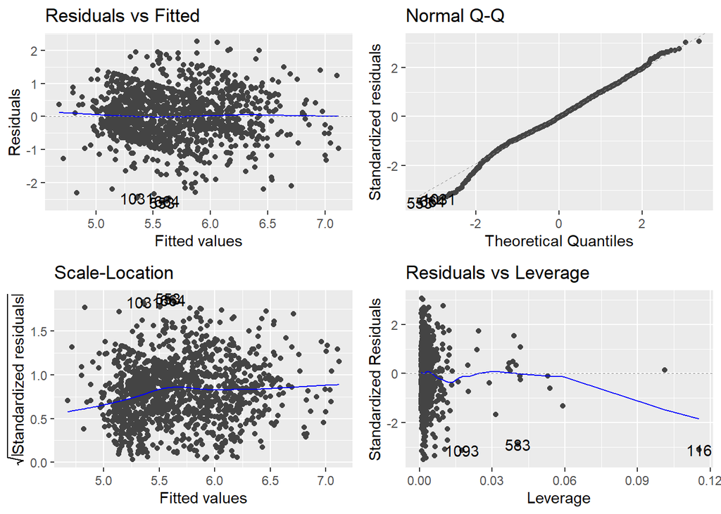

```r
autoplot(model3)
```

Still considered acceptable.

Attempting to another predictor

Looking at remaining by themselves.

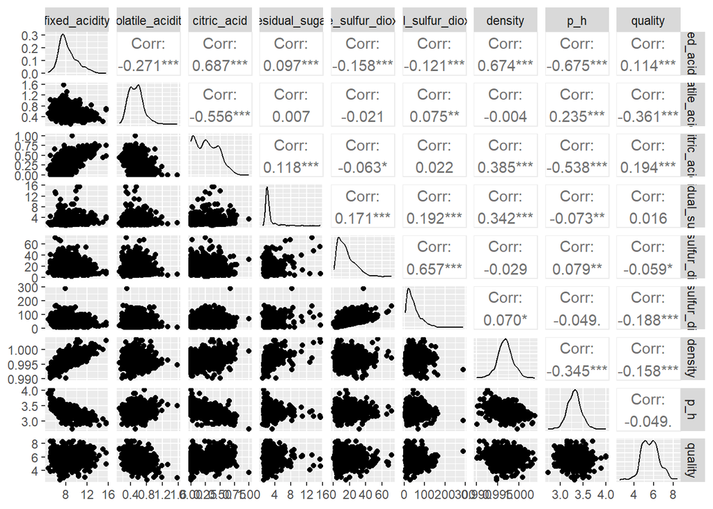

```r
red_train %>%
  select(-region, -alcohol, -sulphates, -chlorides) %>%
  ggpairs()
```

Volatile acidty seems good candidate

```r
model4 <- lm(quality ~ alcohol + sulphates + chlorides + volatile_acidity, data = red_train)
summary(model4)
```

```
##
## Call:
## lm(formula = quality ~ alcohol + sulphates + chlorides + volatile_acidity,
##     data = red_train)
##
## Residuals:
##     Min      1Q  Median      3Q     Max
## -2.6166 -0.4504 -0.0158  0.4854  2.1989
##
## Coefficients:
##                  Estimate Std. Error t value Pr(>|t|)
## (Intercept)       2.83283    0.24288  11.664  < 2e-16 ***
## alcohol           0.28856    0.01995  14.467  < 2e-16 ***
## sulphates         0.89127    0.14193   6.280 4.65e-10 ***
## chlorides        -1.86576    0.48366  -3.858  0.00012 ***
## volatile_acidity -1.13392    0.12074  -9.392  < 2e-16 ***
## ---
## Signif. codes:  0 '***' 0.001 '**' 0.01 '*' 0.05 '.' 0.1 ' ' 1
##
## Residual standard error: 0.7181 on 1275 degrees of freedom
## Multiple R-squared:  0.3002, Adjusted R-squared:  0.298
## F-statistic: 136.8 on 4 and 1275 DF,  p-value: < 2.2e-16
```

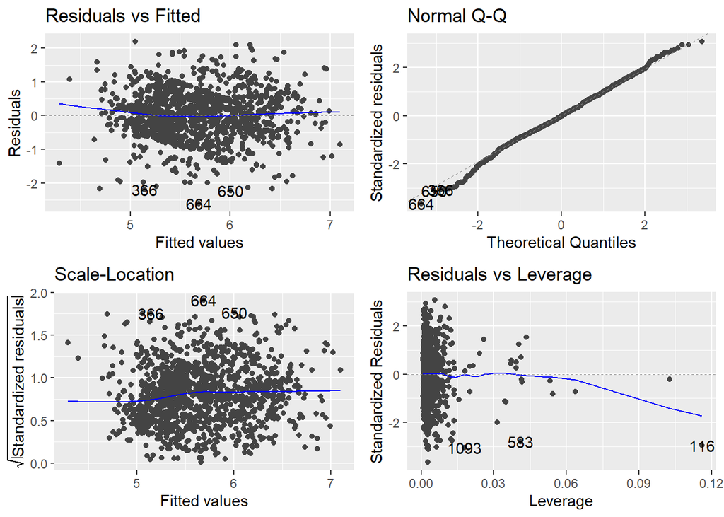

```r
autoplot(model4)
```

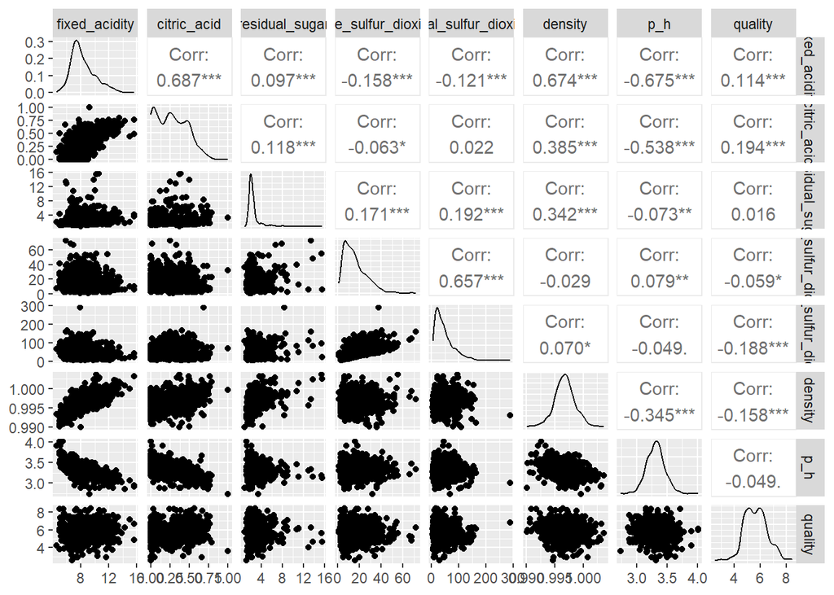

```r
red_train %>%
  select(-region, -alcohol, -sulphates, -chlorides, -volatile_acidity) %>%
  ggpairs()
```

Citric acid?

```r
model5 <- lm(quality ~ alcohol + sulphates + chlorides + volatile_acidity + citric_acid, data = red_train)
summary(model5)
```

```
##
## Call:
## lm(formula = quality ~ alcohol + sulphates + chlorides + volatile_acidity +
##     citric_acid, data = red_train)
##
## Residuals:
##      Min       1Q   Median       3Q      Max
## -2.61397 -0.45359 -0.01446  0.48365  2.20176
##
## Coefficients:
##                  Estimate Std. Error t value Pr(>|t|)
## (Intercept)       2.86938    0.24688  11.623  < 2e-16 ***
## alcohol           0.28939    0.01997  14.488  < 2e-16 ***
## sulphates         0.90529    0.14296   6.333 3.33e-10 ***
## chlorides        -1.77309    0.49647  -3.571 0.000368 ***
## volatile_acidity -1.19657    0.14248  -8.398  < 2e-16 ***
## citric_acid      -0.10798    0.13032  -0.829 0.407474
## ---
## Signif. codes:  0 '***' 0.001 '**' 0.01 '*' 0.05 '.' 0.1 ' ' 1
##
## Residual standard error: 0.7182 on 1274 degrees of freedom
## Multiple R-squared:  0.3006, Adjusted R-squared:  0.2979
## F-statistic: 109.5 on 5 and 1274 DF,  p-value: < 2.2e-16
```

Not significant so sticking with model4.

Now to use test data to assess model.

```r
red_predictions_test <- red_test %>%
  modelr::add_predictions(model4, var = "predicted_quality") %>%
  select(alcohol, sulphates, chlorides, volatile_acidity, quality, predicted_quality)

red_predictions_test
```

| alcohol | sulphates | chlorides | volatile_acidity | quality | predicted_quality |
| --- | --- | --- | --- | --- | --- |
| 9.50 | 0.51 | 0.082 | 0.370 | 4.84 | 5.456156 |
| 10.50 | 0.53 | 0.092 | 0.480 | 5.82 | 5.619153 |
| 9.60 | 0.54 | 0.076 | 0.720 | 4.68 | 5.126074 |
| 9.70 | 0.81 | 0.125 | 0.400 | 5.78 | 5.667005 |
| 11.80 | 0.53 | 0.096 | 0.605 | 6.14 | 5.845078 |
| 12.30 | 0.64 | 0.092 | 0.420 | 6.66 | 6.304635 |
| 10.20 | 0.67 | 0.088 | 0.965 | 4.70 | 5.114877 |
| 9.50 | 0.69 | 0.115 | 0.570 | 5.06 | 5.328232 |
| 9.60 | 0.70 | 0.076 | 0.570 | 5.92 | 5.438766 |
| 8.80 | 0.75 | 0.205 | 0.500 | 4.58 | 5.091173 |

[output cut: 309 more lines]

Now with MSE

```r
red_predictions_test %>%
  mutate(error = predicted_quality - quality,
         error_2 = error ** 2) %>%
  summarise(mse_test = mean(error_2))
```

| mse_test |
| --- |
| 0.446244 |

```r
red_predictions_train <- red_train %>%
  modelr::add_predictions(model4, var = "predicted_quality")


mse_train <- red_predictions_train %>%
  mutate(error = predicted_quality - quality) %>%
  mutate(error_2 = error^2) %>%
  summarise(mse_train = mean(error_2))

mse_train
```

| mse_train |
| --- |
| 0.513699 |

Automated attempt

```r
library(leaps)
red_subsets_forward <- regsubsets(quality ~., data = red_train, nvmax = 12, method = "forward"  )
```

```r
sum_subsets_forward <- summary(red_subsets_forward)
sum_subsets_forward
```

```
## Subset selection object
## Call: regsubsets.formula(quality ~ ., data = red_train, nvmax = 12,
##     method = "forward")
## 15 Variables  (and intercept)
##                      Forced in Forced out
## fixed_acidity            FALSE      FALSE
## volatile_acidity         FALSE      FALSE
## citric_acid              FALSE      FALSE
## residual_sugar           FALSE      FALSE
## chlorides                FALSE      FALSE
## free_sulfur_dioxide      FALSE      FALSE
## total_sulfur_dioxide     FALSE      FALSE
## density                  FALSE      FALSE
## p_h                      FALSE      FALSE
## sulphates                FALSE      FALSE
## alcohol                  FALSE      FALSE
## regionFrance             FALSE      FALSE
## regionItaly              FALSE      FALSE
## regionSpain              FALSE      FALSE
## regionUSA                FALSE      FALSE
## 1 subsets of each size up to 12
## Selection Algorithm: forward
##           fixed_acidity volatile_acidity citric_acid residual_sugar chlorides
## 1  ( 1 )  " "           " "              " "         " "            " "
## 2  ( 1 )  " "           "*"              " "         " "            " "
## 3  ( 1 )  " "           "*"              " "         " "            " "
## 4  ( 1 )  " "           "*"              " "         " "            " "
## 5  ( 1 )  " "           "*"              " "         " "            "*"
## 6  ( 1 )  " "           "*"              " "         " "            "*"
## 7  ( 1 )  " "           "*"              "*"         " "            "*"
## 8  ( 1 )  " "           "*"              "*"         " "            "*"
## 9  ( 1 )  " "           "*"              "*"         " "            "*"
## 10  ( 1 ) "*"           "*"              "*"         " "            "*"
## 11  ( 1 ) "*"           "*"              "*"         "*"            "*"
## 12  ( 1 ) "*"           "*"              "*"         "*"            "*"
##           free_sulfur_dioxide total_sulfur_dioxide density p_h sulphates
## 1  ( 1 )  " "                 " "                  " "     " " " "
## 2  ( 1 )  " "                 " "                  " "     " " " "
## 3  ( 1 )  " "                 " "                  " "     " " "*"
## 4  ( 1 )  " "                 "*"                  " "     " " "*"
## 5  ( 1 )  " "                 "*"                  " "     " " "*"
## 6  ( 1 )  " "                 "*"                  " "     "*" "*"
## 7  ( 1 )  " "                 "*"                  " "     "*" "*"
## 8  ( 1 )  "*"                 "*"                  " "     "*" "*"
## 9  ( 1 )  "*"                 "*"                  " "     "*" "*"
## 10  ( 1 ) "*"                 "*"                  " "     "*" "*"
## 11  ( 1 ) "*"                 "*"                  " "     "*" "*"
## 12  ( 1 ) "*"                 "*"                  "*"     "*" "*"
##           alcohol regionFrance regionItaly regionSpain regionUSA
## 1  ( 1 )  "*"     " "          " "         " "         " "
## 2  ( 1 )  "*"     " "          " "         " "         " "
## 3  ( 1 )  "*"     " "          " "         " "         " "
## 4  ( 1 )  "*"     " "          " "         " "         " "
## 5  ( 1 )  "*"     " "          " "         " "         " "
## 6  ( 1 )  "*"     " "          " "         " "         " "
## 7  ( 1 )  "*"     " "          " "         " "         " "
## 8  ( 1 )  "*"     " "          " "         " "         " "
## 9  ( 1 )  "*"     "*"          " "         " "         " "
## 10  ( 1 ) "*"     "*"          " "         " "         " "
## 11  ( 1 ) "*"     "*"          " "         " "         " "
## 12  ( 1 ) "*"     "*"          " "         " "         " "
```

Model has selected as best predictors in desc order

- alcohol
- volatile acidity
- sulphates
- total sulfur dioxide
- chlorides

```r
sum_subsets_forward$which
```

```
##    (Intercept) fixed_acidity volatile_acidity citric_acid residual_sugar
## 1         TRUE         FALSE            FALSE       FALSE          FALSE
## 2         TRUE         FALSE             TRUE       FALSE          FALSE
## 3         TRUE         FALSE             TRUE       FALSE          FALSE
## 4         TRUE         FALSE             TRUE       FALSE          FALSE
## 5         TRUE         FALSE             TRUE       FALSE          FALSE
## 6         TRUE         FALSE             TRUE       FALSE          FALSE
## 7         TRUE         FALSE             TRUE        TRUE          FALSE
## 8         TRUE         FALSE             TRUE        TRUE          FALSE
## 9         TRUE         FALSE             TRUE        TRUE          FALSE
## 10        TRUE          TRUE             TRUE        TRUE          FALSE
## 11        TRUE          TRUE             TRUE        TRUE           TRUE
## 12        TRUE          TRUE             TRUE        TRUE           TRUE
##    chlorides free_sulfur_dioxide total_sulfur_dioxide density   p_h sulphates
## 1      FALSE               FALSE                FALSE   FALSE FALSE     FALSE
```

[output cut: 24 more lines]

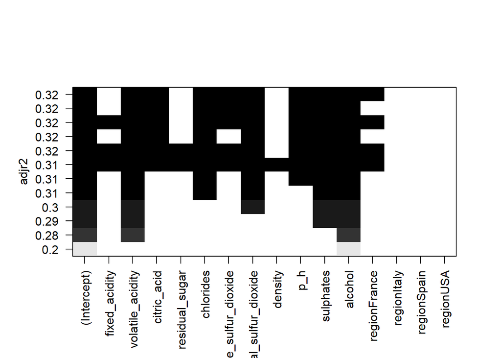

```r
plot(red_subsets_forward, scale = "adjr2")
```

Attemtimng with BIS for increased parsimony (simplicity )

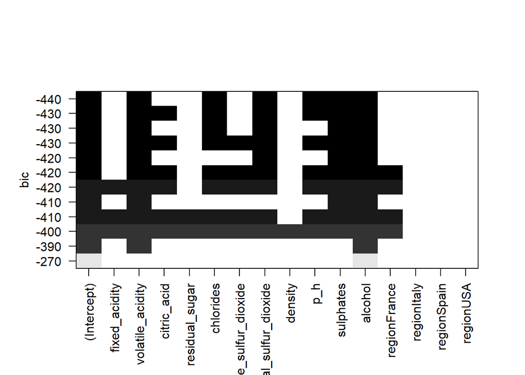

```r
plot(red_subsets_forward, scale = "bic")
```

Indicated model with lowest BIC includes:

volatile acidity, chlorides, total sulfur dioxide, pH, sulfates, alcohol

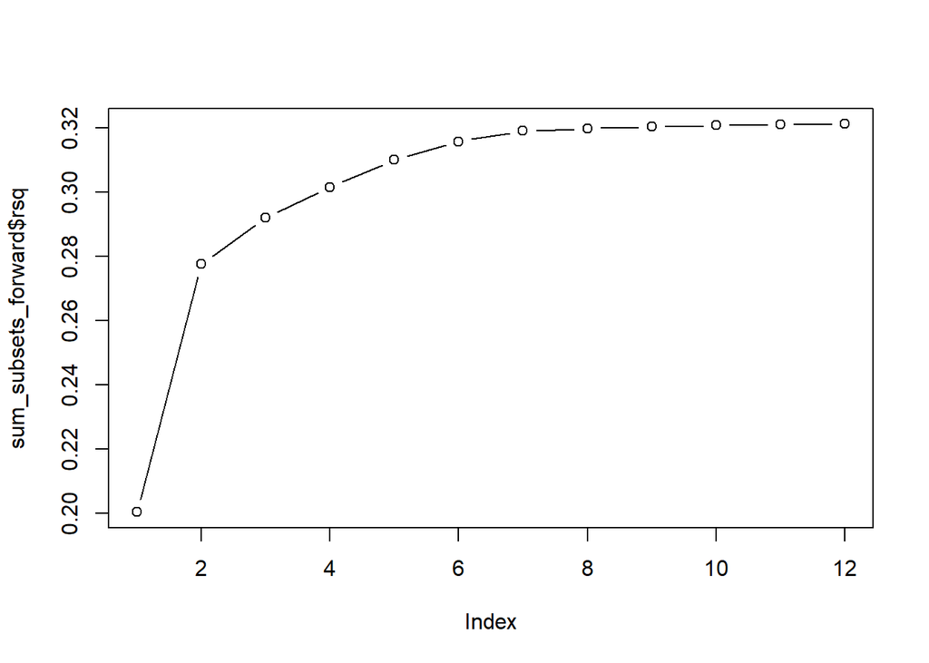

```r
plot(sum_subsets_forward$rsq, type = "b")
```

Around 7 seems indicated, now to penalise measure of fit with BIC

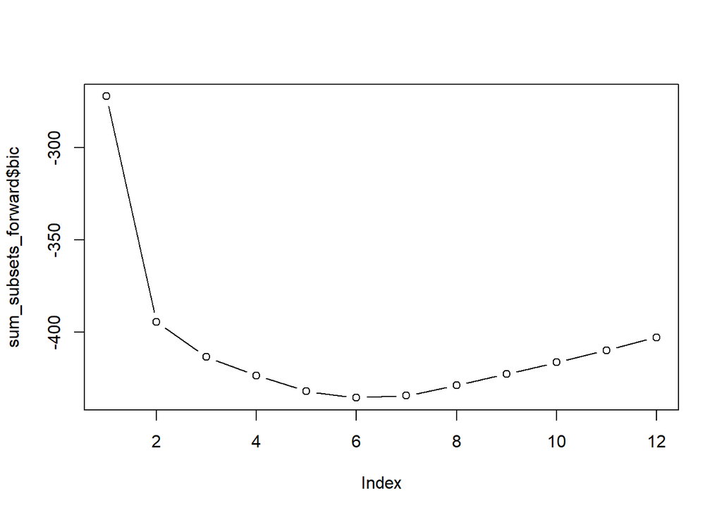

```r
plot(sum_subsets_forward$bic, type = "b")
```

6 shows, fits with shaded boxplot outputs

Build model

```r
auto_model <- lm(quality ~ volatile_acidity + chlorides + total_sulfur_dioxide +
                   p_h + sulphates + alcohol, data = red_train)

summary(auto_model)
```

```
##
## Call:
## lm(formula = quality ~ volatile_acidity + chlorides + total_sulfur_dioxide +
##     p_h + sulphates + alcohol, data = red_train)
##
## Residuals:
##      Min       1Q   Median       3Q      Max
## -2.55054 -0.45132 -0.00532  0.48672  2.11852
##
## Coefficients:
##                        Estimate Std. Error t value Pr(>|t|)
## (Intercept)           4.4880435  0.4933845   9.096  < 2e-16 ***
## volatile_acidity     -0.9941085  0.1244403  -7.989 3.03e-15 ***
## chlorides            -2.2097412  0.4876409  -4.531 6.41e-06 ***
## total_sulfur_dioxide -0.0027407  0.0006361  -4.308 1.77e-05 ***
## p_h                  -0.4753959  0.1455115  -3.267  0.00112 **
## sulphates             0.9066138  0.1410446   6.428 1.83e-10 ***
## alcohol               0.2877793  0.0207201  13.889  < 2e-16 ***
## ---
## Signif. codes:  0 '***' 0.001 '**' 0.01 '*' 0.05 '.' 0.1 ' ' 1
##
## Residual standard error: 0.7107 on 1273 degrees of freedom
## Multiple R-squared:  0.3158, Adjusted R-squared:  0.3126
## F-statistic: 97.93 on 6 and 1273 DF,  p-value: < 2.2e-16
```

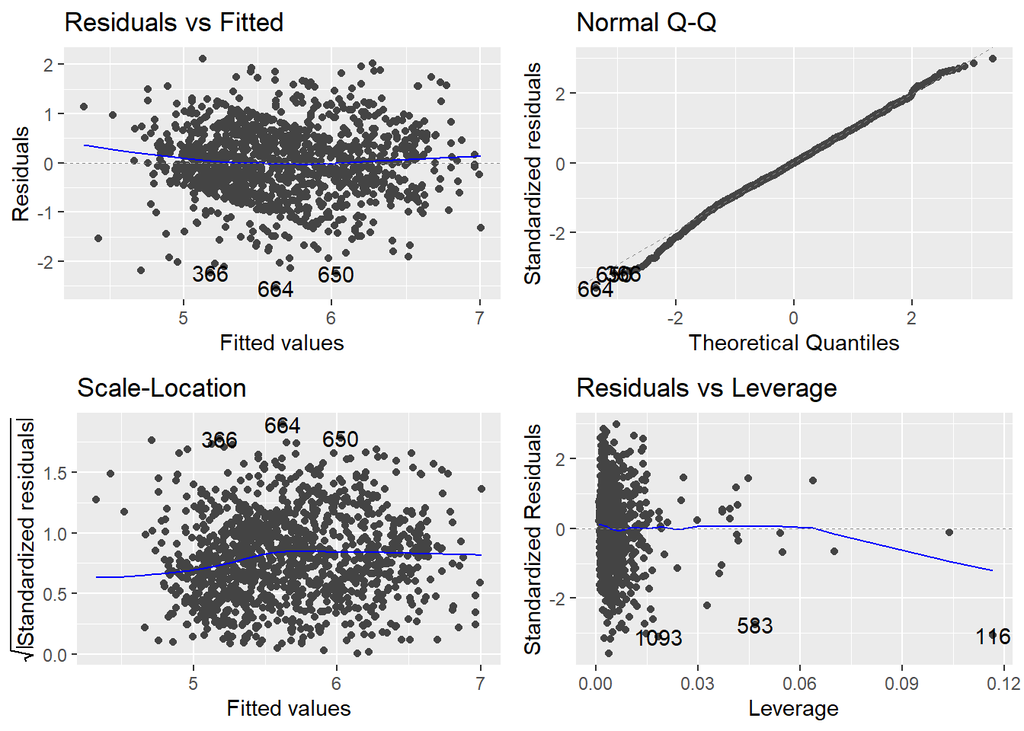

```r
autoplot(auto_model)
```

32% R2, 2% higher than manually made model4, diagnostics look good, RSE marginally lower than model4 at 0.7.

```r
red_predictions_test_auto <- red_test %>%
  modelr::add_predictions(auto_model, var = "predicted_quality") %>%
  select(alcohol, sulphates, chlorides, volatile_acidity, p_h, total_sulfur_dioxide,
         quality, predicted_quality)

red_predictions_test_auto
```

| alcohol | sulphates | chlorides | volatile_acidity | p_h | total_sulfur_dioxide | quality | predicted_quality |
| --- | --- | --- | --- | --- | --- | --- | --- |
| 9.50 | 0.51 | 0.082 | 0.370 | 3.18 | 26 | 4.84 | 5.552285 |
| 10.50 | 0.53 | 0.092 | 0.480 | 3.31 | 52 | 5.82 | 5.593688 |
| 9.60 | 0.54 | 0.076 | 0.720 | 3.39 | 32 | 4.68 | 5.157305 |
| 9.70 | 0.81 | 0.125 | 0.400 | 3.03 | 49 | 5.78 | 5.765257 |
| 11.80 | 0.53 | 0.096 | 0.605 | 3.46 | 31 | 6.14 | 5.820944 |
| 12.30 | 0.64 | 0.092 | 0.420 | 3.78 | 55 | 6.66 | 6.039407 |
| 10.20 | 0.67 | 0.088 | 0.965 | 3.58 | 32 | 4.70 | 5.087433 |
| 9.50 | 0.69 | 0.115 | 0.570 | 3.38 | 16 | 5.06 | 5.376060 |
| 9.60 | 0.70 | 0.076 | 0.570 | 3.36 | 27 | 5.92 | 5.479444 |
| 8.80 | 0.75 | 0.205 | 0.500 | 3.16 | 82 | 4.58 | 5.023425 |

[output cut: 309 more lines]

Now with MSE

```r
red_predictions_test_auto %>%
  mutate(error = predicted_quality - quality,
         error_2 = error ** 2) %>%
  summarise(mse_test_auto = mean(error_2))
```

| mse_test_auto |
| --- |
| 0.4439027 |

```r
red_predictions_train_auto <- red_train %>%
  modelr::add_predictions(auto_model, var = "predicted_quality")


mse_train_auto <- red_predictions_train_auto %>%
  mutate(error = predicted_quality - quality) %>%
  mutate(error_2 = error^2) %>%
  summarise(mse_train_auto = mean(error_2))

mse_train_auto
```

| mse_train_auto |
| --- |
| 0.5022729 |

Final comparsion of models

model4 <- lm(quality ~ alcohol + sulphates + chlorides + volatile_acidity, data = red_train)

auto_model <- lm(quality ~ volatile_acidity + chlorides + total_sulfur_dioxide + p_h + sulphates + alcohol, data = red_train)

```r
AIC(model4)
```

```
## [1] 2791.852
```

```r
BIC(model4)
```

```
## [1] 2822.78
```

```r
AIC(auto_model)
```

```
## [1] 2767.06
```

```r
BIC(auto_model)
```

```
## [1] 2808.297
```

auto_model lower on boths AIC and BIC so is better of two models created.

```r
auto_model
```

```
##
## Call:
## lm(formula = quality ~ volatile_acidity + chlorides + total_sulfur_dioxide +
##     p_h + sulphates + alcohol, data = red_train)
##
## Coefficients:
##          (Intercept)      volatile_acidity             chlorides
##             4.488044             -0.994108             -2.209741
## total_sulfur_dioxide                   p_h             sulphates
##            -0.002741             -0.475396              0.906614
##              alcohol
##             0.287779
```

Works on white wine?

```r
white_model <- lm(quality ~ volatile_acidity + chlorides + total_sulfur_dioxide +
                   p_h + sulphates + alcohol, data = white)

summary(white_model)
```

```
##
## Call:
## lm(formula = quality ~ volatile_acidity + chlorides + total_sulfur_dioxide +
##     p_h + sulphates + alcohol, data = white)
##
## Residuals:
##     Min      1Q  Median      3Q     Max
## -3.6661 -0.5486 -0.0159  0.5242  3.2713
##
## Coefficients:
##                        Estimate Std. Error t value Pr(>|t|)
## (Intercept)           2.1197237  0.2814134   7.532  5.9e-14 ***
## volatile_acidity     -2.0412140  0.1192064 -17.123  < 2e-16 ***
## chlorides            -1.5647195  0.5829278  -2.684  0.00729 **
## total_sulfur_dioxide  0.0009498  0.0003175   2.992  0.00279 **
## p_h                   0.1952859  0.0799732   2.442  0.01465 *
## sulphates             0.2987298  0.1058076   2.823  0.00477 **
## alcohol               0.3350691  0.0114927  29.155  < 2e-16 ***
## ---
## Signif. codes:  0 '***' 0.001 '**' 0.01 '*' 0.05 '.' 0.1 ' ' 1
##
## Residual standard error: 0.8255 on 4891 degrees of freedom
## Multiple R-squared:  0.2306, Adjusted R-squared:  0.2297
## F-statistic: 244.4 on 6 and 4891 DF,  p-value: < 2.2e-16
```

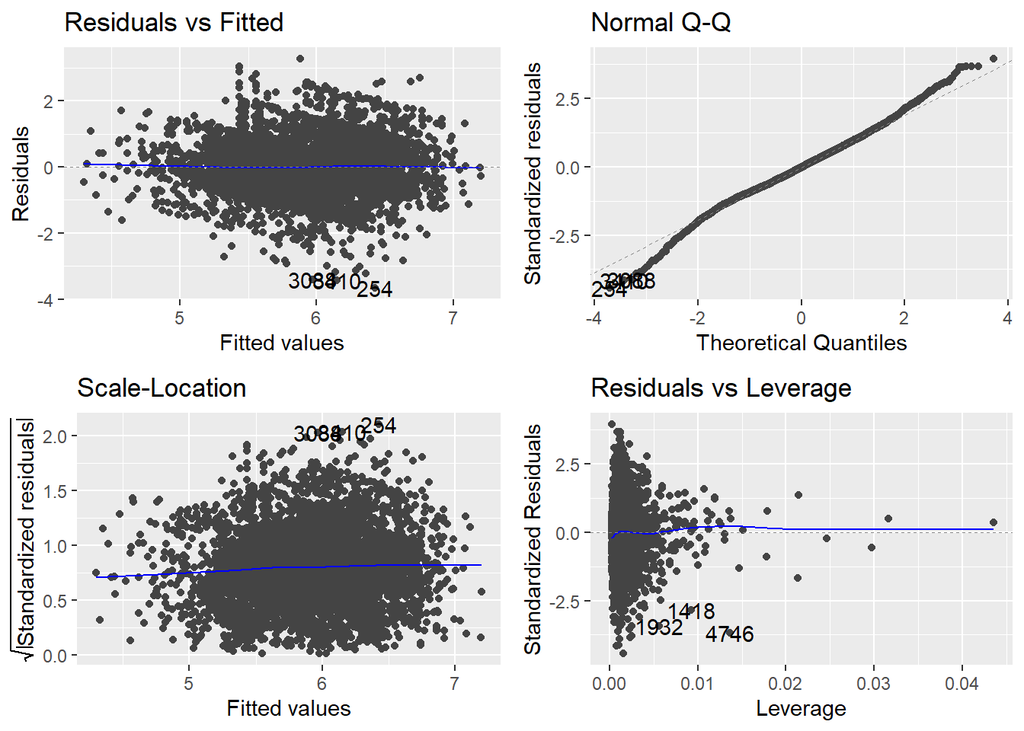

```r
autoplot(white_model)
```

Works ok, diagnostics slight tailing on qq but pretty close. Only issue is R2 bit low.